# Example solution: Simple linear regression

Manuel Villarreal

2024-08-26

### Now it’s your turn.

1. Download the data file `simple-lin-reg.csv` from canvas and using the normal equations seen in lecture estimate the value of the parameters $\beta_0$, $\beta_1$, and $\sigma^2$ for the model:
   $$\text{blood pressure}_i = \beta_0 + \beta_1 *
   \text{age} + \epsilon_i$$
   assuming that $\epsilon_i \overset{iid}{\sim}N(0,\sigma^2)$.

*R:* First we want to read the data into R

```r
# load data from csv file into "blood" object
blood <- read.csv(file = "data/simple-lin-reg.csv")

# obtain sample size by counting the number of rows in the data
n <- dim(blood)[1]
```

From the expression of the OLS estimators we know that the first statistic that we want to calculate is $\hat{\beta}_1$ which is then used to calculate $\hat{\beta}_0$.
$$\hat{\beta}_1 = \frac{\sum_{i = 1}^n(y_i -
\bar{y})(x_{i1} - \bar{x}_1)}{\sum_{i =
1}^n(x_{i1}-\bar{x}_1)^2}$$

```r
# store mean blood pressure
y_bar <- mean(blood$blood_pressure)

# store mean age
x_bar <- mean(blood$age)

# calculate the numerator of the normal equation for hat_beta1
s_xy <- sum(x = (blood$blood_pressure - y_bar) * (blood$age - x_bar))

# calculate the denominator of the normal equation for hat_beta1
s_xx <- sum(x = (blood$age - x_bar)^2)

# calculate the value of hat_beta1
hat_beta1 <- s_xy / s_xx
```

The estimated value of the slope associated with age ($\beta_1$) is: $\hat{\beta}_1 =$ 0.5

With this value now we can estimate the intercept $\beta_0$ using the normal equations:
$$\hat{\beta}_0 = \bar{y} - \hat{\beta}_1
x_{i1}$$

```r
# calculate the value of hat_beta0
hat_beta0 <- y_bar - hat_beta1 * x_bar
```

The estimated value of the intercept ($\beta_0$) is: $\hat{\beta}_0 =$ 104.15

Finally, using these two values and the sample size we can calculate the value of the unbiased variance estimator:
$$\hat{\sigma}^2= \frac{1}{n-p} \sum_{i = 1}^n (y_i
- \hat{\mu}_i)^2$$

```r
# first we calculate the expected value hat_mu of each observation i
hat_mu <- hat_beta0 + hat_beta1 * blood$age

# then we can calculate the Sum Squared Error (SSE)
sse <- sum((blood$blood_pressure - hat_mu)^2)

# using the SSE we can obtain the estimator of the variance hat_sigma2
hat_sigma2 <- 1 / (n - 2) * sse
```

this gives us an estimated variance of: $\hat{\sigma}^2 =$ 13.16

2. Make a scatter plot of the association between blood pressure and age. Add the regression line that you found in step 1.

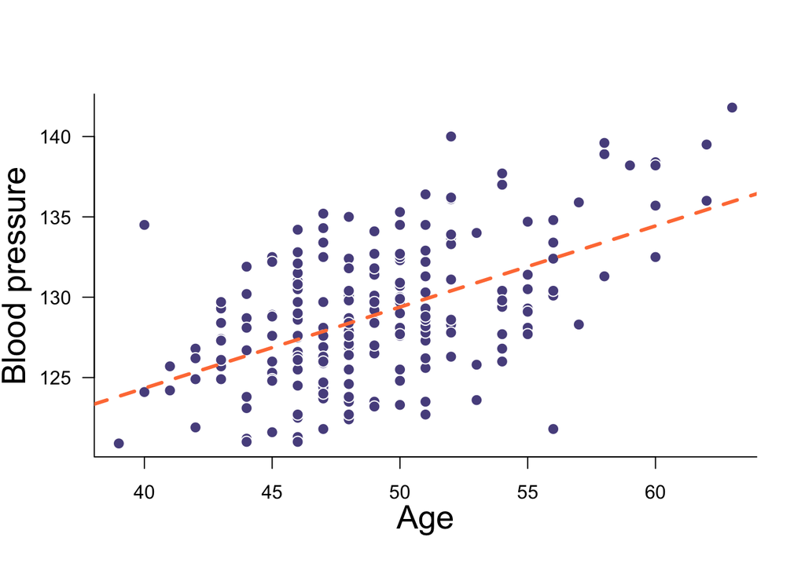

```r
# make a scatter plot of age vs blood pressure
plot(x = blood$age, y = blood$blood_pressure,
     pch = 21, col = "white",  bg = "#58508d", cex = 1.3,
     ann = FALSE, axes = FALSE)

# add an L shape border to plot
box(bty = "l")

# add x-axis tick marks and values
axis(side = 1)

# add y-axis tick marks and values rotated 90 degrees clockwise
axis(side = 2, las = 2)

# add label to x-axis
mtext(text = "Age", side = 1, line = 2.3, cex = 1.7)

# add label to y-axis
mtext(text = "Blood pressure", side = 2, line = 2.8, cex = 1.7)

# add a "curve" to the plot using the curve function
# Note that the x in expr will take the values indicated by "from" up to "to"
curve(expr = hat_beta0 + hat_beta1 * x,
      from = 38, to = 70, add = TRUE,
      lwd = 3, lty = 2, col = "#ff7c43")
```

3. Make a scatter plot that shows the association between blood pressure and age stratified by sex (e.g. using different colors).

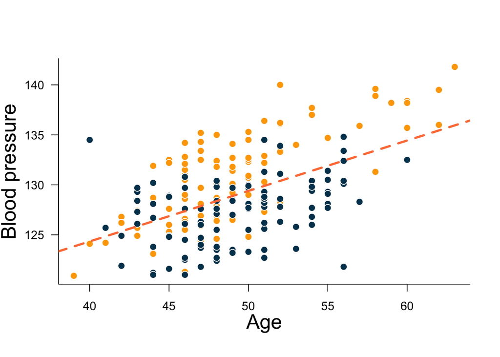

```r
# make a scatter plot of age vs blood pressure, use ifelse
# function to assign the color yellow to female participants
plot(x = blood$age, y = blood$blood_pressure,
     pch = 21, col = "white", cex = 1.3, ann = FALSE, axes = FALSE,
     bg = ifelse(test = blood$sex == "female",
                 yes = "#ffa600",
                 no = "#003f5c"))

# adding details to the plot
box(bty = "l")
axis(side = 1)
axis(side = 2, las = 2)
mtext(text = "Age", side = 1, line = 2.3, cex = 1.7)
mtext(text = "Blood pressure", side = 2, line = 2.8, cex = 1.7)

# add regression line for comparison
curve(expr = hat_beta0 + hat_beta1 * x,
      from = 38, to = 70, add = TRUE,
      lwd = 3, lty = 2, col = "#ff7c43")
```